# Lab Session: Vector Autoregression (VAR) and Structural VAR (SVAR)

Econometrics Lab

2026-03-27

# 1 Introduction

## 1.1 What Is a VAR?

A **Vector Autoregression (VAR)** is a system of equations where each variable is regressed on its own lags and the lags of all other variables in the system. It generalizes the univariate AR model to a multivariate setting.

For a bivariate VAR(1) with variables $y_t$ and $x_t$:

$$\begin{aligned}
y_t &= c_1 + a_{11} y_{t-1} + a_{12} x_{t-1} + u_{1t} \\
x_t &= c_2 + a_{21} y_{t-1} + a_{22} x_{t-1} + u_{2t}
\end{aligned}$$

In matrix form: $\mathbf{Y}_t = \mathbf{c} + \mathbf{A}_1 \mathbf{Y}_{t-1} + \mathbf{u}_t$

**Key features:**

- Every variable is endogenous
- No contemporaneous terms on the RHS (only lags)
- The error terms $u_t$ may be correlated across equations

## 1.2 Why VAR?

- Captures dynamic interdependencies among multiple time series
- Useful for forecasting, Granger causality testing, and impulse response analysis
- Minimal structural assumptions required

## 1.3 Reduced-Form vs. Structural

|  | Reduced-Form VAR | Structural VAR (SVAR) |
| --- | --- | --- |
| **Contemporaneous effects** | Hidden in error covariance | Explicitly modeled |
| **Errors** | Correlated ($\Sigma_u$) | Orthogonal structural shocks ($\varepsilon_t$) |
| **Identification** | Not needed | Requires restrictions |
| **Impulse responses** | Not structurally interpretable | Economically meaningful |

# 2 Setup: Packages and Data

```r
# Install packages if needed (uncomment the lines below on first run)
# install.packages(c("vars", "svars", "urca", "tidyverse", "tseries", "lmtest"))

library(vars)       # VAR estimation and tools
library(svars)      # Structural VAR identification
library(urca)       # Unit root / cointegration tests
library(tseries)    # Additional time series tests
library(lmtest)     # Granger causality
library(tidyverse)  # Data manipulation and plotting
```

## 2.1 Load the Data

We use the **Canada** dataset built into the `vars` package. It contains four quarterly macroeconomic time series for Canada (1980Q1–2000Q4):

- `e` — Employment
- `prod` — Labor productivity
- `rw` — Real wage
- `U` — Unemployment rate

```r
data("Canada")

# Inspect the data
cat("Class:", class(Canada), "\n")
```

```
## Class: mts ts
```

```r
cat("Dimensions:", dim(Canada), "\n")
```

```
## Dimensions: 84 4
```

```r
cat("Time range:", start(Canada), "to", end(Canada), "\n\n")
```

```
## Time range: 1980 1 to 2000 4
```

```r
head(Canada)
```

```
##                e     prod       rw    U
## 1980 Q1 929.6105 405.3665 386.1361 7.53
## 1980 Q2 929.8040 404.6398 388.1358 7.70
## 1980 Q3 930.3184 403.8149 390.5401 7.47
## 1980 Q4 931.4277 404.2158 393.9638 7.27
## 1981 Q1 932.6620 405.0467 396.7647 7.37
## 1981 Q2 933.5509 404.4167 400.0217 7.13
```

## 2.2 Visualize the Series

Always plot your data before modeling!

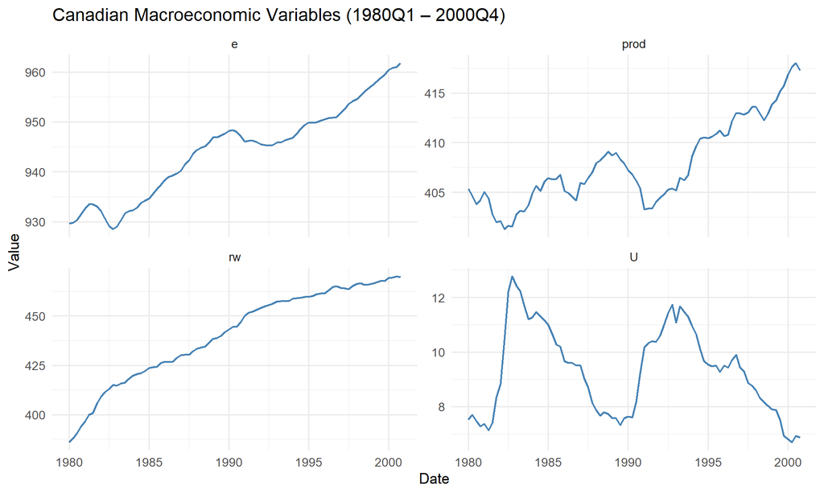

```r
# Convert to data frame for ggplot
canada_df <- data.frame(
  date = as.Date(time(Canada)),
  as.data.frame(Canada)
)

canada_long <- canada_df %>%
  pivot_longer(cols = -date, names_to = "variable", values_to = "value")

ggplot(canada_long, aes(x = date, y = value)) +
  geom_line(color = "steelblue", linewidth = 0.8) +
  facet_wrap(~ variable, scales = "free_y", ncol = 2) +
  labs(title = "Canadian Macroeconomic Variables (1980Q1 – 2000Q4)",
       x = "Date", y = "Value") +
  theme_minimal(base_size = 13)
```

> **Discussion:** Do the series look stationary? Which ones appear to have trends or unit roots?

# 3 Preliminary Analysis

## 3.1 Unit Root Tests

Before estimating a VAR, we need to determine the order of integration for each series.

```r
# ADF test for each variable
cat("=== Augmented Dickey-Fuller Tests ===\n")
```

```
## === Augmented Dickey-Fuller Tests ===
```

```r
cat("H0: The series has a unit root (non-stationary)\n\n")
```

```
## H0: The series has a unit root (non-stationary)
```

```r
for (var_name in colnames(Canada)) {
  adf_result <- adf.test(Canada[, var_name])
  cat(sprintf("%-6s: ADF stat = %6.3f, p-value = %.4f  %s\n",
              var_name, adf_result$statistic, adf_result$p.value,
              ifelse(adf_result$p.value < 0.05, "[STATIONARY]", "[NON-STATIONARY]")))
}
```

```
## e     : ADF stat = -2.148, p-value = 0.5152  [NON-STATIONARY]
## prod  : ADF stat = -2.872, p-value = 0.2180  [NON-STATIONARY]
## rw    : ADF stat = -2.056, p-value = 0.5530  [NON-STATIONARY]
## U     : ADF stat = -2.599, p-value = 0.3303  [NON-STATIONARY]
```

> **Interpretation:** If a series is non-stationary (fail to reject H0), we might consider:
> 1. Differencing the data and estimating a VAR in differences
> 2. Estimating a VAR in levels (valid if the VAR is stable — see Lütkepohl 2005)
> 3. Using a VECM if cointegration is present

> For this lab, we proceed with the data **in levels**, which is a common practice in applied macro when the focus is impulse responses.

# 4 VAR Estimation

## 4.1 Step 1: Lag Order Selection

Choosing the right number of lags is critical. Too few → omitted dynamics and autocorrelated residuals. Too many → loss of degrees of freedom and overfitting.

```r
# VARselect tests up to lag p_max
lag_select <- VARselect(Canada, lag.max = 8, type = "const")

cat("=== Information Criteria by Lag Order ===\n\n")
```

```
## === Information Criteria by Lag Order ===
```

```r
print(lag_select$selection)
```

```
## AIC(n)  HQ(n)  SC(n) FPE(n)
##      3      2      1      3
```

```r
cat("\n--- Full IC Table ---\n")
```

```
##
## --- Full IC Table ---
```

```r
print(round(lag_select$criteria, 2))
```

```
##            1     2     3     4     5     6     7     8
## AIC(n) -6.01 -6.49 -6.59 -6.41 -6.16 -6.06 -5.81 -5.80
## HQ(n)  -5.76 -6.05 -5.95 -5.57 -5.13 -4.84 -4.39 -4.18
## SC(n)  -5.39 -5.39 -5.00 -4.32 -3.59 -3.00 -2.26 -1.75
## FPE(n)  0.00  0.00  0.00  0.00  0.00  0.00  0.00  0.00
```

The most commonly used criteria:

- **AIC** (Akaike): Tends to choose more lags — good for capturing dynamics
- **SC/BIC** (Schwarz/Bayesian): Penalizes more heavily — parsimonious models
- **HQ** (Hannan-Quinn): A middle ground

## 4.2 Step 2: Estimate the VAR

```r
# Estimate VAR with the lag order chosen by BIC
p_bic <- lag_select$selection["SC(n)"]
cat("Selected lag order (BIC):", p_bic, "\n\n")
```

```
## Selected lag order (BIC): 1
```

```r
var_model <- VAR(Canada, p = p_bic, type = "const")

# Summary of one equation (e.g., the Employment equation)
cat("=== Employment Equation ===\n")
```

```
## === Employment Equation ===
```

```r
summary(var_model$varresult$e)
```

```
##
## Call:
## lm(formula = y ~ -1 + ., data = datamat)
##
## Residuals:
##      Min       1Q   Median       3Q      Max
## -1.53117 -0.21104  0.02751  0.28837  0.96233
##
## Coefficients:
##           Estimate Std. Error t value Pr(>|t|)
## e.l1       1.17354    0.08196  14.319  < 2e-16 ***
## prod.l1    0.14479    0.02741   5.282 1.13e-06 ***
## rw.l1     -0.07905    0.02832  -2.791  0.00660 **
## U.l1       0.52438    0.16574   3.164  0.00222 **
## const   -192.56361   63.81154  -3.018  0.00344 **
## ---
## Signif. codes:  0 '***' 0.001 '**' 0.01 '*' 0.05 '.' 0.1 ' ' 1
##
## Residual standard error: 0.4798 on 78 degrees of freedom
## Multiple R-squared:  0.9973, Adjusted R-squared:  0.9972
## F-statistic:  7304 on 4 and 78 DF,  p-value: < 2.2e-16
```

## 4.3 Understanding the Output

```r
# Extract all coefficient matrices
cat("=== VAR Coefficient Matrices ===\n\n")
```

```
## === VAR Coefficient Matrices ===
```

```r
# For each lag, show the A matrix
for (i in 1:p_bic) {
  cat(sprintf("--- A_%d (Lag %d coefficients) ---\n", i, i))
  # Extract coefficients for lag i
  coef_matrix <- sapply(var_model$varresult, function(eq) {
    coefs <- coef(eq)
    # Get coefficients for this lag (variable names end in .li)
    lag_pattern <- paste0("\\.l", i, "$")
    coefs[grep(lag_pattern, names(coefs))]
  })
  print(round(coef_matrix, 4))
  cat("\n")
}
```

```
## --- A_1 (Lag 1 coefficients) ---
##               e    prod      rw       U
## e.l1     1.1735  0.0871  0.0638 -0.1929
## prod.l1  0.1448  1.0197 -0.1355 -0.0809
## rw.l1   -0.0790 -0.0263  0.9687  0.0754
## U.l1     0.5244  0.3230 -0.1954  0.4753
```

```r
# Residual covariance matrix (this is the key object linking VAR to SVAR)
cat("--- Residual Covariance Matrix (Sigma_u) ---\n")
```

```
## --- Residual Covariance Matrix (Sigma_u) ---
```

```r
print(round(summary(var_model)$covres, 6))
```

```
##              e      prod        rw         U
## e     0.230199  0.053107 -0.102932 -0.140554
## prod  0.053107  0.479033  0.026166 -0.029127
## rw   -0.102932  0.026166  0.622809  0.080917
## U    -0.140554 -0.029127  0.080917  0.128753
```

```r
cat("\n--- Residual Correlation Matrix ---\n")
```

```
##
## --- Residual Correlation Matrix ---
```

```r
print(round(summary(var_model)$corres, 4))
```

```
##            e    prod      rw       U
## e     1.0000  0.1599 -0.2718 -0.8164
## prod  0.1599  1.0000  0.0479 -0.1173
## rw   -0.2718  0.0479  1.0000  0.2857
## U    -0.8164 -0.1173  0.2857  1.0000
```

> **Key insight:** The off-diagonal elements in the correlation matrix tell us how much the reduced-form shocks co-move. If they are large, ordering matters a lot for impulse responses!

# 5 Diagnostic Checks

A well-specified VAR should have residuals that are approximately white noise.

## 5.1 Serial Correlation Test

```r
# Portmanteau test (multivariate Ljung-Box)
serial_test <- serial.test(var_model, lags.pt = 16, type = "PT.asymptotic")

cat("=== Portmanteau Test for Serial Correlation ===\n")
```

```
## === Portmanteau Test for Serial Correlation ===
```

```r
cat("H0: No serial correlation up to lag 16\n")
```

```
## H0: No serial correlation up to lag 16
```

```r
cat(sprintf("Chi-sq = %.3f, df = %d, p-value = %.4f\n",
            serial_test$serial$statistic,
            serial_test$serial$parameter,
            serial_test$serial$p.value))
```

```
## Chi-sq = 231.692, df = 240, p-value = 0.6380
```

```r
cat(ifelse(serial_test$serial$p.value > 0.05,
           "=> Fail to reject H0: No evidence of serial correlation.\n",
           "=> Reject H0: Serial correlation detected! Consider adding more lags.\n"))
```

```
## => Fail to reject H0: No evidence of serial correlation.
```

## 5.2 Stability Check

The VAR is stable (stationary) if all eigenvalues of the companion matrix lie inside the unit circle.

```r
# Check stability
roots_var <- roots(var_model)

cat("=== Stability Check ===\n")
```

```
## === Stability Check ===
```

```r
cat("Eigenvalue moduli of companion matrix:\n")
```

```
## Eigenvalue moduli of companion matrix:
```

```r
print(round(roots_var, 4))
```

```
## [1] 0.9928 0.9526 0.9526 0.7511
```

```r
cat(sprintf("\nMax modulus: %.4f\n", max(roots_var)))
```

```
##
## Max modulus: 0.9928
```

```r
cat(ifelse(all(roots_var < 1),
           "=> All roots inside unit circle: VAR is STABLE.\n",
           "=> WARNING: Roots outside unit circle — VAR is NOT stable!\n"))
```

```
## => All roots inside unit circle: VAR is STABLE.
```

# 6 Granger Causality

Granger causality tests whether lags of one variable help predict another, beyond the latter’s own lags.

**Formally:** $x$ Granger-causes $y$ if past values of $x$ contain information useful for predicting $y$, beyond what is contained in past values of $y$ alone.

```r
cat("=== Granger Causality Tests ===\n")
```

```
## === Granger Causality Tests ===
```

```r
cat("H0: [column variable] does NOT Granger-cause [row variable]\n\n")
```

```
## H0: [column variable] does NOT Granger-cause [row variable]
```

```r
vars_list <- colnames(Canada)

# Create a summary table
granger_results <- data.frame(
  Cause = character(),
  Effect = character(),
  F_stat = numeric(),
  p_value = numeric(),
  Conclusion = character(),
  stringsAsFactors = FALSE
)

for (cause_var in vars_list) {
  gc <- causality(var_model, cause = cause_var)
  # The test is: cause_var Granger-causes the remaining variables
  f_val <- gc$Granger$statistic
  p_val <- gc$Granger$p.value
  cat(sprintf("%s => {others}: F = %.3f, p = %.4f  %s\n",
              cause_var, f_val, p_val,
              ifelse(p_val < 0.05, "[SIGNIFICANT]", "[not significant]")))
}
```

```
## e => {others}: F = 4.007, p = 0.0080  [SIGNIFICANT]
## prod => {others}: F = 10.415, p = 0.0000  [SIGNIFICANT]
## rw => {others}: F = 4.257, p = 0.0058  [SIGNIFICANT]
## U => {others}: F = 3.582, p = 0.0142  [SIGNIFICANT]
```

> **Caution:** Granger causality ≠ true causality. It only measures predictive content. A variable can Granger-cause another due to a common omitted driver.

# 7 Impulse Response Functions (IRFs)

## 7.1 Reduced-Form (Cholesky) IRFs

The most common approach uses a **Cholesky decomposition** of the residual covariance matrix. This imposes a recursive (triangular) ordering: the first variable is not contemporaneously affected by shocks to any other variable; the second is affected only by the first, and so on.

**The ordering matters!** Variables ordered first are treated as more “exogenous.”

```r
# Default ordering: e, prod, rw, U (as they appear in the data)
cat("Variable ordering:", paste(colnames(Canada), collapse = " -> "), "\n")
```

```
## Variable ordering: e -> prod -> rw -> U
```

```r
cat("Interpretation: e is most exogenous, U is most endogenous\n\n")
```

```
## Interpretation: e is most exogenous, U is most endogenous
```

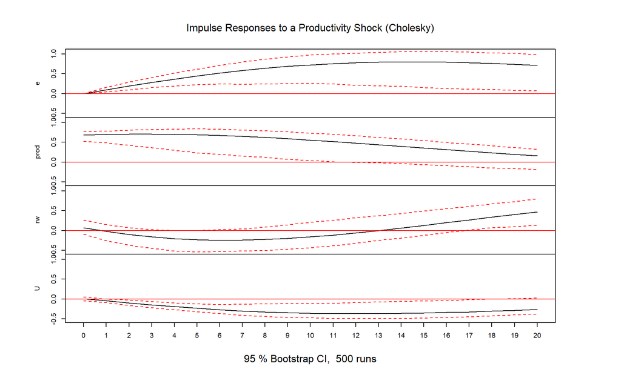

```r
# IRF: shock to productivity -> all variables
irf_prod <- irf(var_model,
                impulse = "prod",
                response = c("e", "prod", "rw", "U"),
                n.ahead = 20,
                boot = TRUE,
                ci = 0.95,
                runs = 500)

plot(irf_prod, main = "Impulse Responses to a Productivity Shock (Cholesky)")
```

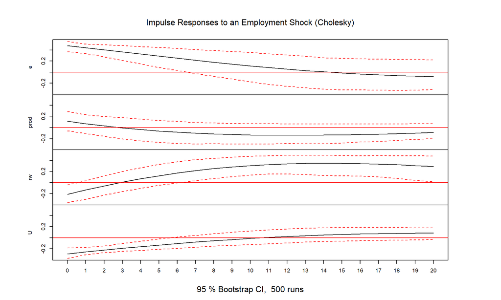

```r
# IRF: shock to employment -> all variables
irf_e <- irf(var_model,
             impulse = "e",
             response = c("e", "prod", "rw", "U"),
             n.ahead = 20,
             boot = TRUE,
             ci = 0.95,
             runs = 500)

plot(irf_e, main = "Impulse Responses to an Employment Shock (Cholesky)")
```

## 7.2 How Sensitive Is the Ordering?

Let’s compare two different orderings to see if the results change materially.

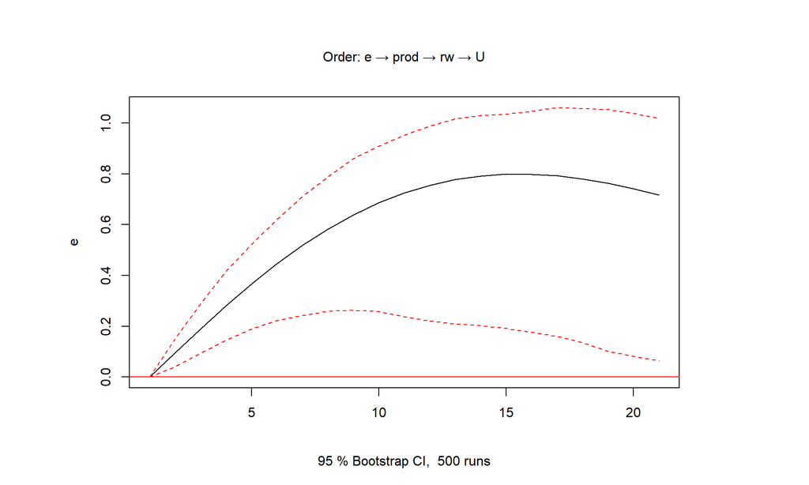

```r
# Ordering 1: e, prod, rw, U (original)
var_order1 <- VAR(Canada[, c("e", "prod", "rw", "U")], p = p_bic, type = "const")

# Ordering 2: U, rw, prod, e (reversed)
var_order2 <- VAR(Canada[, c("U", "rw", "prod", "e")], p = p_bic, type = "const")

irf1 <- irf(var_order1, impulse = "prod", response = "e", n.ahead = 20,
            boot = TRUE, runs = 500)
irf2 <- irf(var_order2, impulse = "prod", response = "e", n.ahead = 20,
            boot = TRUE, runs = 500)

# Compare
par(mfrow = c(1, 2))
plot(irf1, main = "Order: e → prod → rw → U")
```

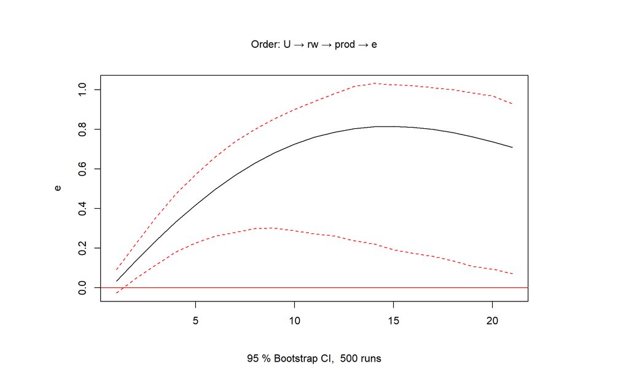

```r
plot(irf2, main = "Order: U → rw → prod → e")
```

```r
par(mfrow = c(1, 1))
```

> **Takeaway:** If results change substantially with ordering, you should use a **Structural VAR** with theory-motivated identification instead of relying on arbitrary Cholesky orderings.

# 8 Forecasting with VAR

```r
# Generate forecasts
var_forecast <- predict(var_model, n.ahead = 8, ci = 0.95)

# Numerical forecast for employment
cat("=== 8-Quarter Ahead Forecast for Employment ===\n")
```

```
## === 8-Quarter Ahead Forecast for Employment ===
```

```r
print(round(var_forecast$fcst$e, 3))
```

```
##         fcst   lower   upper    CI
## [1,] 963.000 962.060 963.940 0.940
## [2,] 964.096 962.783 965.410 1.313
## [3,] 965.070 963.440 966.700 1.630
## [4,] 965.933 963.993 967.872 1.939
## [5,] 966.695 964.441 968.949 2.254
## [6,] 967.365 964.788 969.943 2.578
## [7,] 967.952 965.044 970.859 2.907
## [8,] 968.461 965.221 971.702 3.240
```